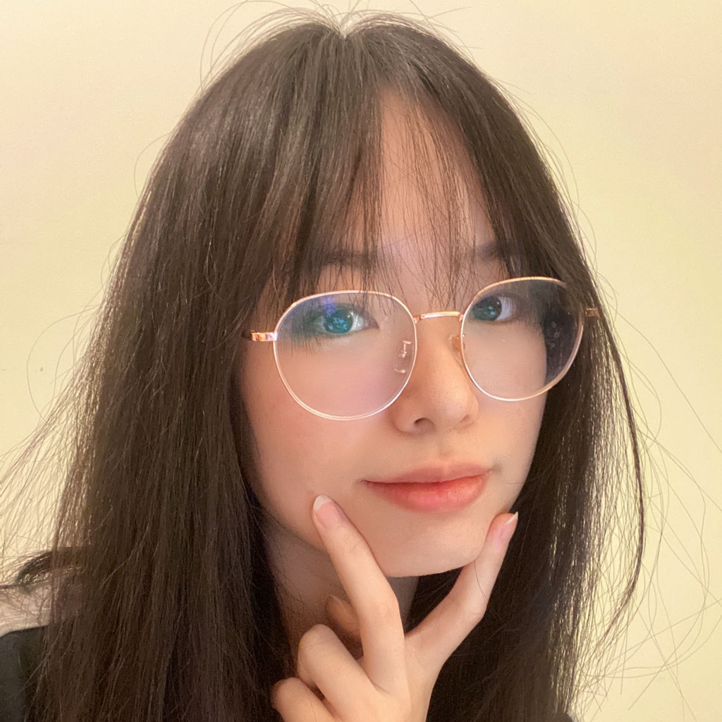

# Qing (Chelsea) Wen

## Bio

I, as a recent graduate from the University of Toronto, am an international student from China. I have been in Canada for about 8 years and finished high-school and post-secondary education in Ottawa and Toronto respectively. Being apart from my family each year gave me a huge opportunity for my personal development as I learned how to look after myself independently while taking good care of my school work. Throughout the time I stayed in Canada, I am deeply moved by the niceties people have shown me. I love the stunning inclusiveness Toronto has (but never the weather). Feeling comfortable studying and living in Toronto, together with a continuing interest in working with data and mining for their underlying insights, I decided to pursue a master’s degree at Rotman Commerce, where I will be studying management analytics. Hopefully, I will utilize these skills to settle myself for a job in business analytics. Currently, I have lots of experience using R, and some experience with Python and SQL, and I have many experiences working in a group tackling course projects and RA work.

Setting aside studying, I am also really into oil painting, exercising, video editing, and *watching* volleyball games (Big fan of the Chinese Female Volleyball Team!).

## Education

**University of Toronto, School of Graduate Studies** | Toronto, ON

Master of Management Analytics | August 2022 - June 2023

**University of Toronto** | Toronto, ON

Honours Bachelor of Science, Applied Statistics Specialist | September 2018 - June 2022

## Experience

**Department of Statistical Sciences, University of Toronto** | Research Assistant | April 2022

**Johnson & Johnson (Shanghai) Medical Device Company** | Marketing Intern | May 2019 - August 2019